# Feature Selection Using R

Katheu

7/15/2021

## Defining the Question

I am a Data analyst at Carrefour Kenya and I’m currently undertaking a project that will inform the marketing department on the most relevant marketing strategies that will result in the highest no. of sales (total price including tax). My project has been divided into four parts where I’ll explore a recent marketing dataset by performing various unsupervised learning techniques and later providing recommendations based on my insights. This section requires us to perform feature selection through the use of the unsupervised learning methods. I will perform my analysis and provide insights on the features that contribute the most information to the dataset.

## Loading the Dataset

I have been provided a sales dataset to perform feature selection on. Let’s dive in by loading and previewing the dataset at hand.

```r
sales <- read.csv("http://bit.ly/CarreFourDataset")
```

### Previewing the top of our dataset

```r
head(sales)
```

```
##    Invoice.ID Branch Customer.type Gender           Product.line Unit.price
## 1 750-67-8428      A        Member Female      Health and beauty      74.69
## 2 226-31-3081      C        Normal Female Electronic accessories      15.28
## 3 631-41-3108      A        Normal   Male     Home and lifestyle      46.33
## 4 123-19-1176      A        Member   Male      Health and beauty      58.22
## 5 373-73-7910      A        Normal   Male      Sports and travel      86.31
## 6 699-14-3026      C        Normal   Male Electronic accessories      85.39
##   Quantity     Tax      Date  Time     Payment   cogs gross.margin.percentage
## 1        7 26.1415  1/5/2019 13:08     Ewallet 522.83                4.761905
## 2        5  3.8200  3/8/2019 10:29        Cash  76.40                4.761905
## 3        7 16.2155  3/3/2019 13:23 Credit card 324.31                4.761905
## 4        8 23.2880 1/27/2019 20:33     Ewallet 465.76                4.761905
## 5        7 30.2085  2/8/2019 10:37     Ewallet 604.17                4.761905
## 6        7 29.8865 3/25/2019 18:30     Ewallet 597.73                4.761905
##   gross.income Rating    Total
## 1      26.1415    9.1 548.9715
## 2       3.8200    9.6  80.2200
## 3      16.2155    7.4 340.5255
## 4      23.2880    8.4 489.0480
## 5      30.2085    5.3 634.3785
## 6      29.8865    4.1 627.6165
```

### Previewing the bottom of our dataset.

```r
tail(sales)
```

```
##       Invoice.ID Branch Customer.type Gender           Product.line Unit.price
## 995  652-49-6720      C        Member Female Electronic accessories      60.95
## 996  233-67-5758      C        Normal   Male      Health and beauty      40.35
## 997  303-96-2227      B        Normal Female     Home and lifestyle      97.38
## 998  727-02-1313      A        Member   Male     Food and beverages      31.84
## 999  347-56-2442      A        Normal   Male     Home and lifestyle      65.82
## 1000 849-09-3807      A        Member Female    Fashion accessories      88.34
##      Quantity     Tax      Date  Time Payment   cogs gross.margin.percentage
## 995         1  3.0475 2/18/2019 11:40 Ewallet  60.95                4.761905
## 996         1  2.0175 1/29/2019 13:46 Ewallet  40.35                4.761905
## 997        10 48.6900  3/2/2019 17:16 Ewallet 973.80                4.761905
## 998         1  1.5920  2/9/2019 13:22    Cash  31.84                4.761905
## 999         1  3.2910 2/22/2019 15:33    Cash  65.82                4.761905
## 1000        7 30.9190 2/18/2019 13:28    Cash 618.38                4.761905
##      gross.income Rating     Total
## 995        3.0475    5.9   63.9975
## 996        2.0175    6.2   42.3675
## 997       48.6900    4.4 1022.4900
## 998        1.5920    7.7   33.4320
## 999        3.2910    4.1   69.1110
## 1000      30.9190    6.6  649.2990
```

## Data Exploration

Checking the Structure of our dataset

```r
str(sales)
```

```
## 'data.frame':    1000 obs. of  16 variables:
##  $ Invoice.ID             : chr  "750-67-8428" "226-31-3081" "631-41-3108" "123-19-1176" ...
##  $ Branch                 : chr  "A" "C" "A" "A" ...
##  $ Customer.type          : chr  "Member" "Normal" "Normal" "Member" ...
##  $ Gender                 : chr  "Female" "Female" "Male" "Male" ...
##  $ Product.line           : chr  "Health and beauty" "Electronic accessories" "Home and lifestyle" "Health and beauty" ...
##  $ Unit.price             : num  74.7 15.3 46.3 58.2 86.3 ...
##  $ Quantity               : int  7 5 7 8 7 7 6 10 2 3 ...
##  $ Tax                    : num  26.14 3.82 16.22 23.29 30.21 ...
##  $ Date                   : chr  "1/5/2019" "3/8/2019" "3/3/2019" "1/27/2019" ...
##  $ Time                   : chr  "13:08" "10:29" "13:23" "20:33" ...
##  $ Payment                : chr  "Ewallet" "Cash" "Credit card" "Ewallet" ...
##  $ cogs                   : num  522.8 76.4 324.3 465.8 604.2 ...
##  $ gross.margin.percentage: num  4.76 4.76 4.76 4.76 4.76 ...
##  $ gross.income           : num  26.14 3.82 16.22 23.29 30.21 ...
##  $ Rating                 : num  9.1 9.6 7.4 8.4 5.3 4.1 5.8 8 7.2 5.9 ...
##  $ Total                  : num  549 80.2 340.5 489 634.4 ...
```

Our dataset has 1000 rows and 16 columns. 8 of which have a character data type, one is an integer and the other 7 are numerical.

Checking our dataset’s summary.

```r
summary(sales)
```

```
##   Invoice.ID           Branch          Customer.type         Gender
##  Length:1000        Length:1000        Length:1000        Length:1000
##  Class :character   Class :character   Class :character   Class :character
##  Mode  :character   Mode  :character   Mode  :character   Mode  :character
##
##
##
##  Product.line         Unit.price       Quantity          Tax
##  Length:1000        Min.   :10.08   Min.   : 1.00   Min.   : 0.5085
##  Class :character   1st Qu.:32.88   1st Qu.: 3.00   1st Qu.: 5.9249
##  Mode  :character   Median :55.23   Median : 5.00   Median :12.0880
##                     Mean   :55.67   Mean   : 5.51   Mean   :15.3794
##                     3rd Qu.:77.94   3rd Qu.: 8.00   3rd Qu.:22.4453
##                     Max.   :99.96   Max.   :10.00   Max.   :49.6500
##      Date               Time             Payment               cogs
##  Length:1000        Length:1000        Length:1000        Min.   : 10.17
##  Class :character   Class :character   Class :character   1st Qu.:118.50
##  Mode  :character   Mode  :character   Mode  :character   Median :241.76
##                                                           Mean   :307.59
##                                                           3rd Qu.:448.90
##                                                           Max.   :993.00
##  gross.margin.percentage  gross.income         Rating           Total
##  Min.   :4.762           Min.   : 0.5085   Min.   : 4.000   Min.   :  10.68
##  1st Qu.:4.762           1st Qu.: 5.9249   1st Qu.: 5.500   1st Qu.: 124.42
##  Median :4.762           Median :12.0880   Median : 7.000   Median : 253.85
##  Mean   :4.762           Mean   :15.3794   Mean   : 6.973   Mean   : 322.97
##  3rd Qu.:4.762           3rd Qu.:22.4453   3rd Qu.: 8.500   3rd Qu.: 471.35
##  Max.   :4.762           Max.   :49.6500   Max.   :10.000   Max.   :1042.65
```

## Data Cleaning

Checking for missing values

```r
colSums(is.na(sales))
```

```
##              Invoice.ID                  Branch           Customer.type
##                       0                       0                       0
##                  Gender            Product.line              Unit.price
##                       0                       0                       0
##                Quantity                     Tax                    Date
##                       0                       0                       0
##                    Time                 Payment                    cogs
##                       0                       0                       0
## gross.margin.percentage            gross.income                  Rating
##                       0                       0                       0
##                   Total
##                       0
```

There are no missing values in this dataset.

Checking for duplicates.

```r
sales[duplicated(sales),]
```

```
##  [1] Invoice.ID              Branch                  Customer.type
##  [4] Gender                  Product.line            Unit.price
##  [7] Quantity                Tax                     Date
## [10] Time                    Payment                 cogs
## [13] gross.margin.percentage gross.income            Rating
## [16] Total
## <0 rows> (or 0-length row.names)
```

There are no duplicates in our dataset.

Checking for outliers.

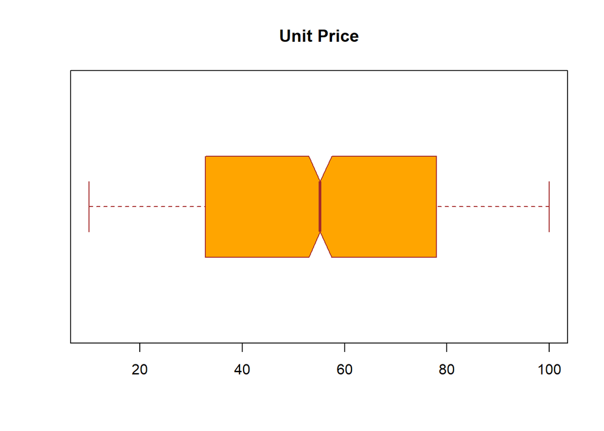

```r
boxplot(sales$Unit.price,
        main ="Unit Price",
        col = "orange",
        border  = 'brown',
        horizontal = TRUE,
        notch = TRUE)
```

There are no outliers in the Unit price column.

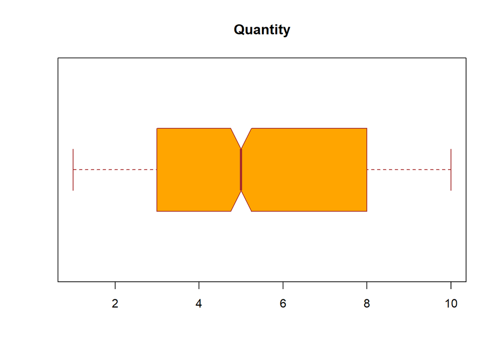

```r
boxplot(sales$Quantity,
        main ="Quantity",
        col = "orange",
        border  = 'brown',
        horizontal = TRUE,
        notch = TRUE)
```

There are no outliers in the quantity column.

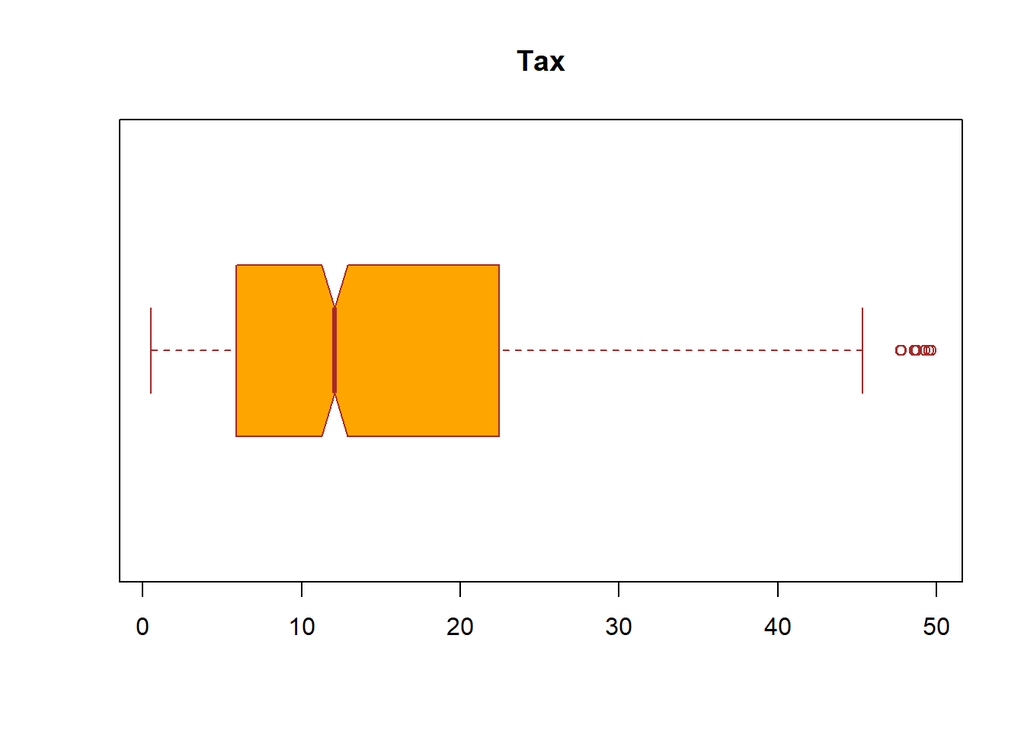

```r
boxplot(sales$Tax,
        main ="Tax",
        col = "orange",
        border  = 'brown',
        horizontal = TRUE,
        notch = TRUE)
```

There are a few outliers in the Tax column.

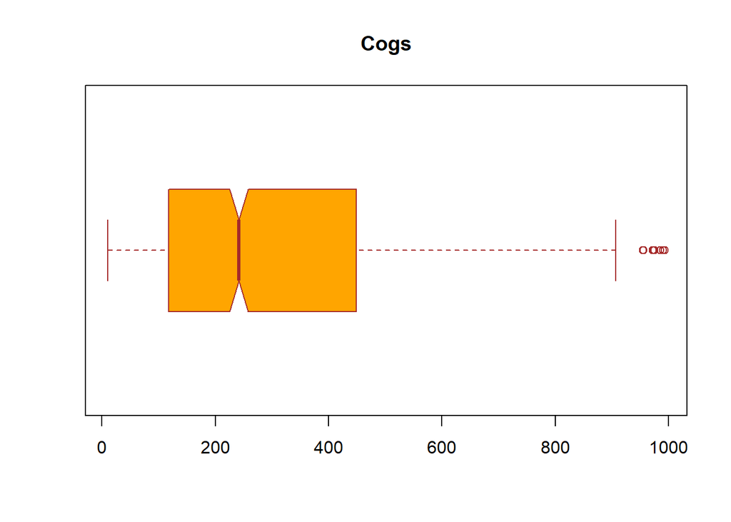

```r
boxplot(sales$cogs,
        main ="Cogs",
        col = "orange",
        border  = 'brown',
        horizontal = TRUE,
        notch = TRUE)
```

There are a few outliers in the cogs column.

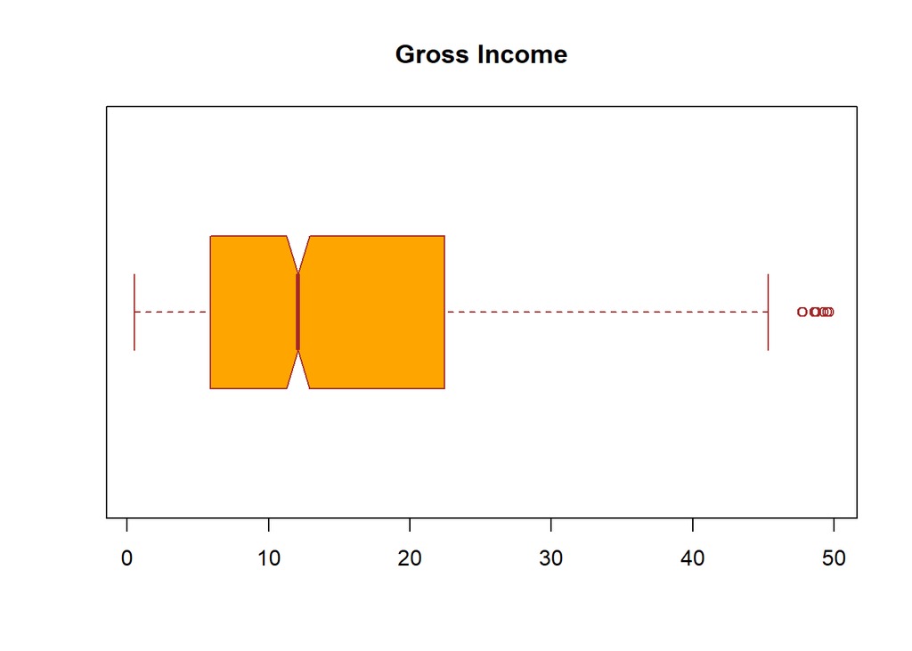

```r
boxplot(sales$gross.income,
        main ="Gross Income",
        col = "orange",
        border  = 'brown',
        horizontal = TRUE,
        notch = TRUE)
```

There are a few outliers in the gross income column.

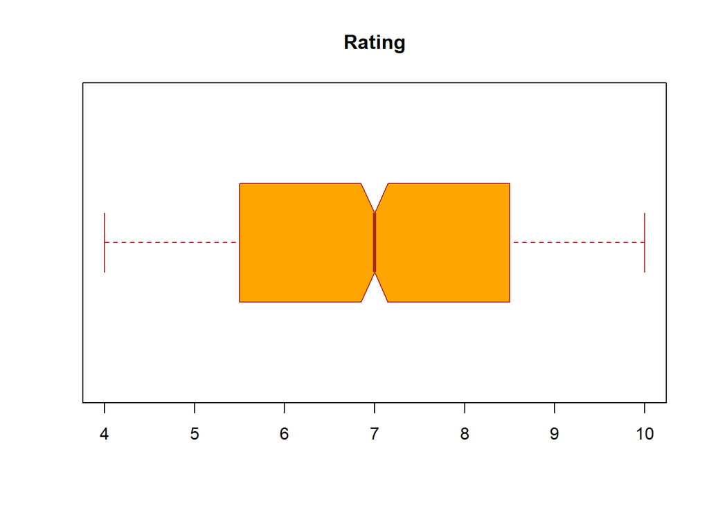

```r
boxplot(sales$Rating,
        main ="Rating",
        col = "orange",
        border  = 'brown',
        horizontal = TRUE,
        notch = TRUE)
```

## Exploratory Data Analysis

### Univariate Analysis

#### Measures of Central Tendency

Finding the mean of our numeric columns

```r
colMeans(sales[sapply(sales,is.numeric)])
```

```
##              Unit.price                Quantity                     Tax
##               55.672130                5.510000               15.379369
##                    cogs gross.margin.percentage            gross.income
##              307.587380                4.761905               15.379369
##                  Rating                   Total
##                6.972700              322.966749
```

Finding the median of our numeric columns.

```r
unitprice_median <- median(sales$Unit.price)
qty_median <- median(sales$Quantity)
tax_median <- median(sales$Tax)
cogs_median <- median(sales$cogs)
income_median <- median(sales$gross.income)
rating_median <- median (sales$Rating)

unitprice_median
```

```
## [1] 55.23
```

```r
qty_median
```

```
## [1] 5
```

```r
tax_median
```

```
## [1] 12.088
```

```r
cogs_median
```

```
## [1] 241.76
```

```r
income_median
```

```
## [1] 12.088
```

```r
rating_median
```

```
## [1] 7
```

Finding the mode of our numeric columns. Let’s create the mode function since it’s not inbuilt.

```r
getmode <- function(v) {
   uniqv <- unique(v)
   uniqv[which.max(tabulate(match(v, uniqv)))]}
```

```r
getmode(sales$Unit.price)
```

```
## [1] 83.77
```

```r
getmode(sales$Quantity)
```

```
## [1] 10
```

```r
getmode(sales$Tax)
```

```
## [1] 39.48
```

```r
getmode(sales$cogs)
```

```
## [1] 789.6
```

```r
getmode(sales$gross.income)
```

```
## [1] 39.48
```

```r
getmode(sales$Rating)
```

```
## [1] 6
```

Finding the range in our columns. The results will give us the minimum and maximum values in our numeric columns.

```r
range(sales$Unit.price)
```

```
## [1] 10.08 99.96
```

```r
range(sales$Quantity)
```

```
## [1]  1 10
```

```r
range(sales$Tax)
```

```
## [1]  0.5085 49.6500
```

```r
range(sales$cogs)
```

```
## [1]  10.17 993.00
```

```r
range(sales$gross.income)
```

```
## [1]  0.5085 49.6500
```

```r
range(sales$Rating)
```

```
## [1]  4 10
```

Getting the quantiles in our columns.

```r
quantile(sales$Unit.price)
```

```
##     0%    25%    50%    75%   100%
## 10.080 32.875 55.230 77.935 99.960
```

```r
quantile(sales$Quantity)
```

```
##   0%  25%  50%  75% 100%
##    1    3    5    8   10
```

```r
quantile(sales$Tax)
```

```
##        0%       25%       50%       75%      100%
##  0.508500  5.924875 12.088000 22.445250 49.650000
```

```r
quantile(sales$cogs)
```

```
##       0%      25%      50%      75%     100%
##  10.1700 118.4975 241.7600 448.9050 993.0000
```

```r
quantile(sales$gross.income)
```

```
##        0%       25%       50%       75%      100%
##  0.508500  5.924875 12.088000 22.445250 49.650000
```

```r
quantile(sales$Rating)
```

```
##   0%  25%  50%  75% 100%
##  4.0  5.5  7.0  8.5 10.0
```

Finding the variance of the numeric columns. This shows how the data values are dispersed around the mean.

```r
var(sales$Unit.price)
```

```
## [1] 701.9653
```

```r
var(sales$Quantity)
```

```
## [1] 8.546446
```

```r
var(sales$Tax)
```

```
## [1] 137.0966
```

```r
var(sales$cogs)
```

```
## [1] 54838.64
```

```r
var(sales$gross.income)
```

```
## [1] 137.0966
```

```r
var(sales$Rating)
```

```
## [1] 2.953518
```

Finding the standard deviation of our numeric columns.

```r
sd(sales$Unit.price)
```

```
## [1] 26.49463
```

```r
sd(sales$Quantity)
```

```
## [1] 2.923431
```

```r
sd(sales$Tax)
```

```
## [1] 11.70883
```

```r
sd(sales$cogs)
```

```
## [1] 234.1765
```

```r
sd(sales$gross.income)
```

```
## [1] 11.70883
```

```r
sd(sales$Rating)
```

```
## [1] 1.71858
```

#### Histograms

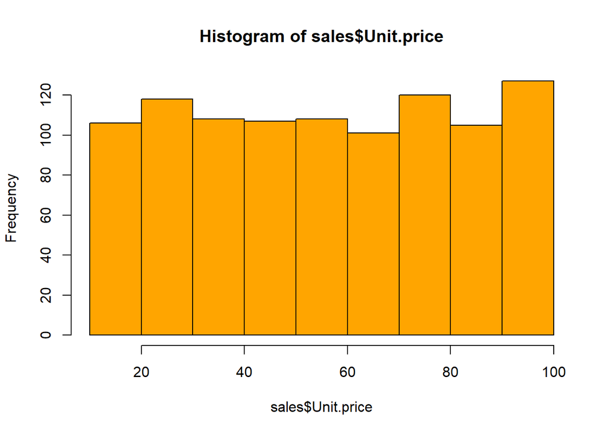

```r
hist(sales$Unit.price, col  = "orange")
```

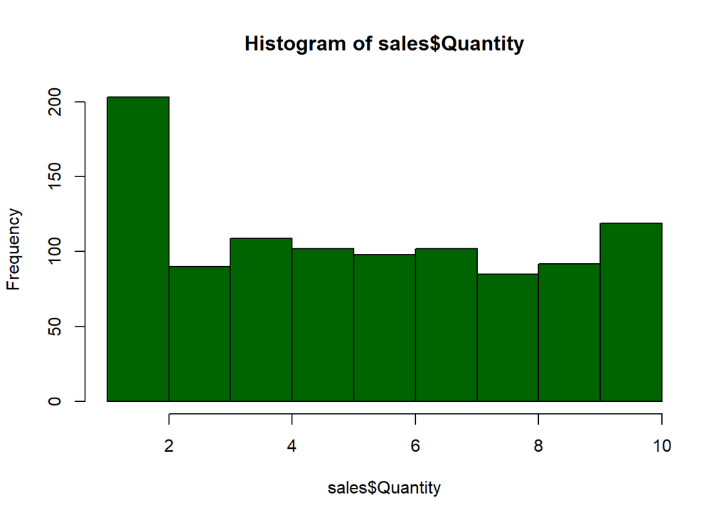

```r
hist(sales$Quantity, col  = "dark green")
```

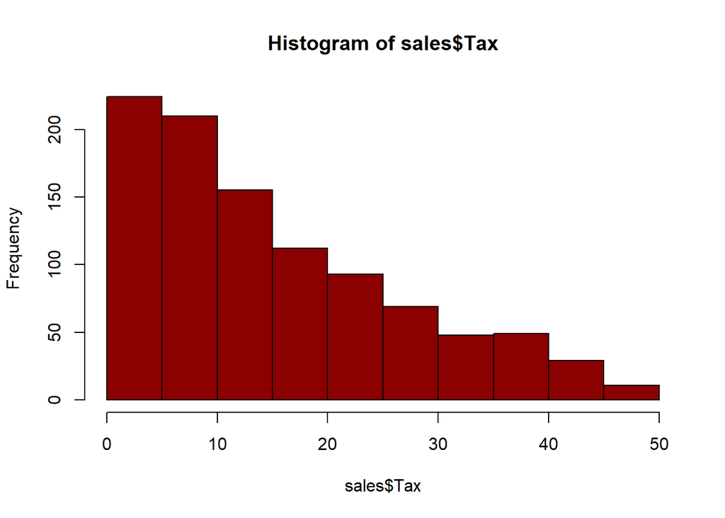

```r
hist(sales$Tax, col = "dark red")
```

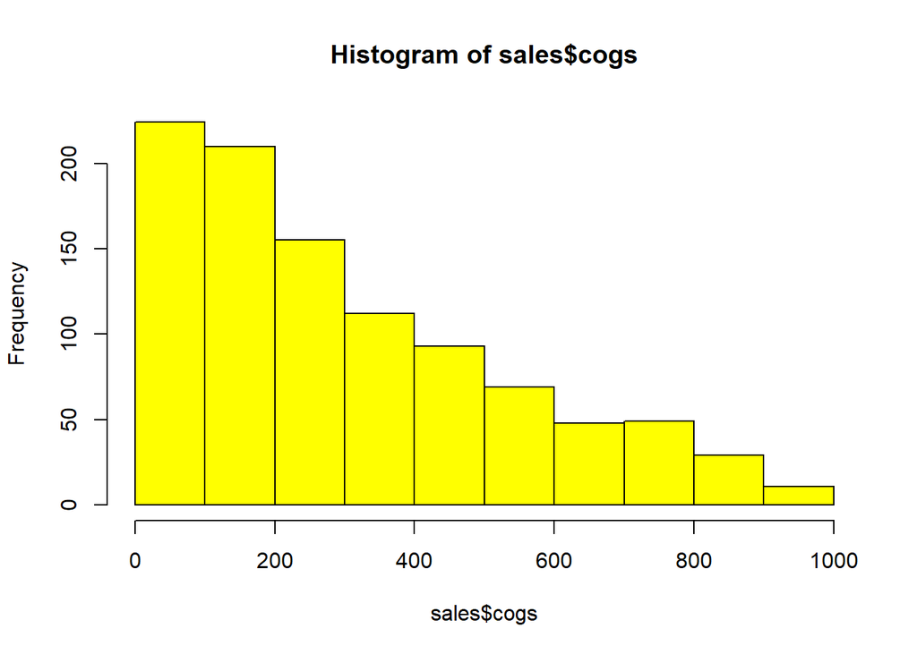

```r
hist(sales$cogs, col = "yellow")
```

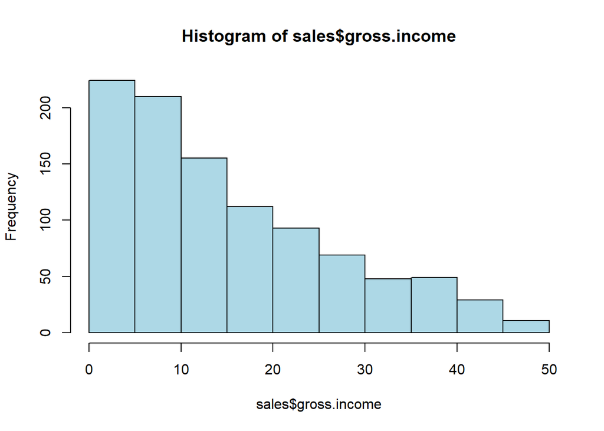

```r
hist(sales$gross.income, col= "light blue")
```

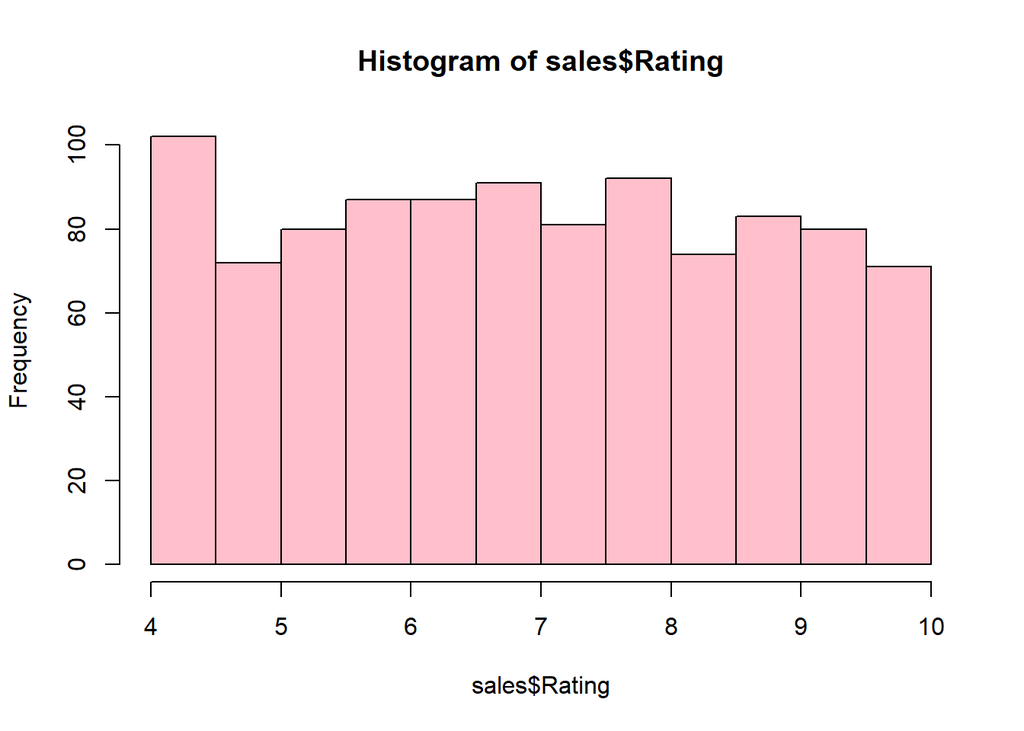

```r
hist(sales$Rating, col  ="pink")
```

### Bivariate Analysis

#### Correlation

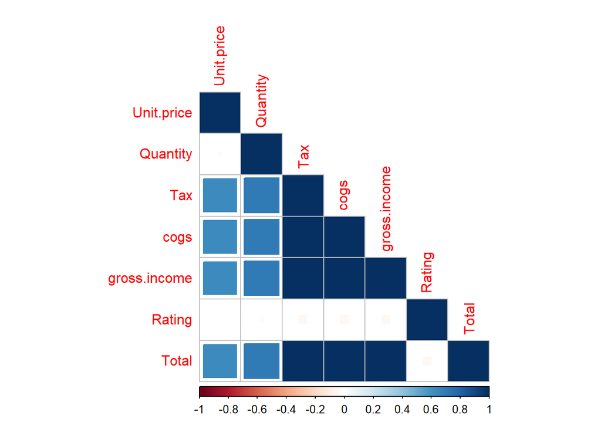

```r
library(corrplot)
correlation <- cor(sales[,c(6,7,8,12,14,15,16)])
corrplot(correlation, method = "square", type = "lower", diag = TRUE)
```

Most of our variables have very strong correlations.

## Feature Selection

### Filter Methods

These methods apply a metric to assign a scoring to each feature. The features would then be ranked by the score. We will use the findCorrelation function included in the caret package to create a subset of variables. This function will allow us to remove redundancy by correlation using the given dataset. Since we are working with a correlation matrix, we’ll only use the numerical variables.

```r
df <- sales[,c(6,7,8,12,14,15,16)]
head(df)
```

```
##   Unit.price Quantity     Tax   cogs gross.income Rating    Total
## 1      74.69        7 26.1415 522.83      26.1415    9.1 548.9715
## 2      15.28        5  3.8200  76.40       3.8200    9.6  80.2200
## 3      46.33        7 16.2155 324.31      16.2155    7.4 340.5255
## 4      58.22        8 23.2880 465.76      23.2880    8.4 489.0480
## 5      86.31        7 30.2085 604.17      30.2085    5.3 634.3785
## 6      85.39        7 29.8865 597.73      29.8865    4.1 627.6165
```

Loading our caret package.

```r
suppressWarnings(
        suppressMessages(if
                         (!require(caret, quietly=TRUE))
                install.packages("caret")))
library(caret)
```

Installing the corrplot package for correlation.

```r
suppressWarnings(
        suppressMessages(if
                         (!require(corrplot, quietly=TRUE))
                install.packages("corrplot")))
library(corrplot)
```

Getting the correlation matrix

```r
corrmatrix <- cor(df)
corrmatrix
```

```
##                Unit.price    Quantity        Tax       cogs gross.income
## Unit.price    1.000000000  0.01077756  0.6339621  0.6339621    0.6339621
## Quantity      0.010777564  1.00000000  0.7055102  0.7055102    0.7055102
## Tax           0.633962089  0.70551019  1.0000000  1.0000000    1.0000000
## cogs          0.633962089  0.70551019  1.0000000  1.0000000    1.0000000
## gross.income  0.633962089  0.70551019  1.0000000  1.0000000    1.0000000
## Rating       -0.008777507 -0.01581490 -0.0364417 -0.0364417   -0.0364417
## Total         0.633962089  0.70551019  1.0000000  1.0000000    1.0000000
##                    Rating      Total
## Unit.price   -0.008777507  0.6339621
## Quantity     -0.015814905  0.7055102
## Tax          -0.036441705  1.0000000
## cogs         -0.036441705  1.0000000
## gross.income -0.036441705  1.0000000
## Rating        1.000000000 -0.0364417
## Total        -0.036441705  1.0000000
```

Finding variables that are highly correlated

```r
highlyCorrelated <- findCorrelation(corrmatrix, cutoff=0.75)
highlyCorrelated
```

```
## [1] 4 7 3
```

Let’s get the names of these highly correlated variables.

```r
names(df[,highlyCorrelated])
```

```
## [1] "cogs"  "Total" "Tax"
```

From our output, the cogs, total and tax columns have the highest correlations.

Removing redundant features.

```r
df2<-df[-highlyCorrelated]
df2
```

```
##      Unit.price Quantity gross.income Rating
## 1         74.69        7      26.1415    9.1
## 2         15.28        5       3.8200    9.6
## 3         46.33        7      16.2155    7.4
## 4         58.22        8      23.2880    8.4
## 5         86.31        7      30.2085    5.3
## 6         85.39        7      29.8865    4.1
## 7         68.84        6      20.6520    5.8
## 8         73.56       10      36.7800    8.0
## 9         36.26        2       3.6260    7.2
## 10        54.84        3       8.2260    5.9
## 11        14.48        4       2.8960    4.5
## 12        25.51        4       5.1020    6.8
## 13        46.95        5      11.7375    7.1
## 14        43.19       10      21.5950    8.2
```

[output cut: 986 more lines]

Graphical comparison.

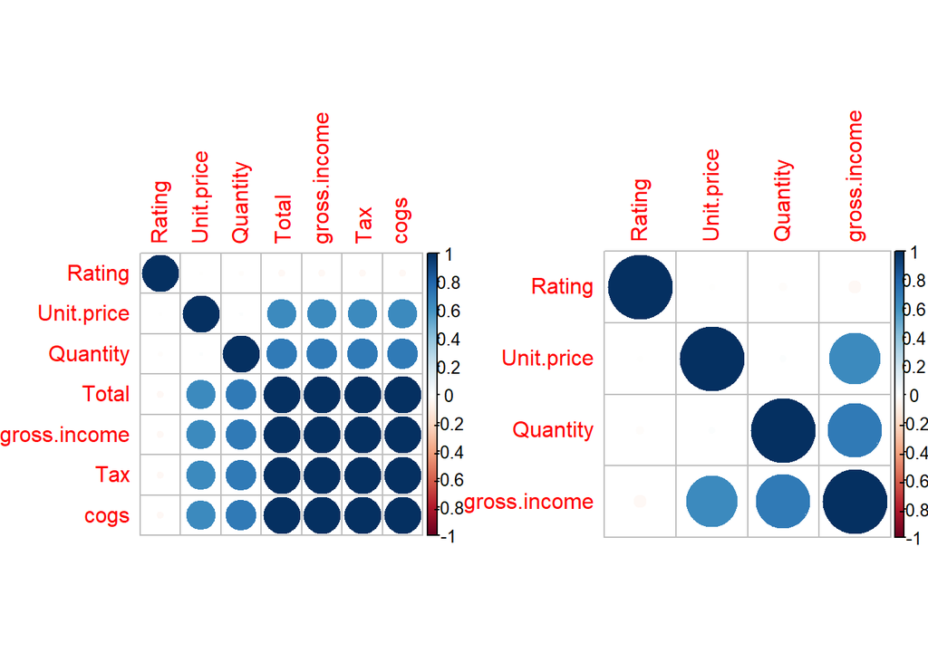

```r
par(mfrow = c(1, 2))
corrplot(corrmatrix, order = "hclust")
corrplot(cor(df2), order = "hclust")
```

### Embedded Methods

We will use the ewkm function from the wskm package. This is a weighted subspace clustering algorithm that is well suited to very high dimensional data.

Loading our wskm package.

```r
suppressWarnings(
        suppressMessages(if
                         (!require(wskm, quietly=TRUE))
                install.packages("wskm")))
library(wskm)
```

```r
set.seed(23)
model <- ewkm(df, 3, lambda=2, maxiter=1000)
```

Loading the cluster package.

```r
suppressWarnings(
        suppressMessages(if
                         (!require(cluster, quietly=TRUE))
                install.packages("cluster")))
library("cluster")
```

Let’s cluster plot against the 1st 2 principal components.

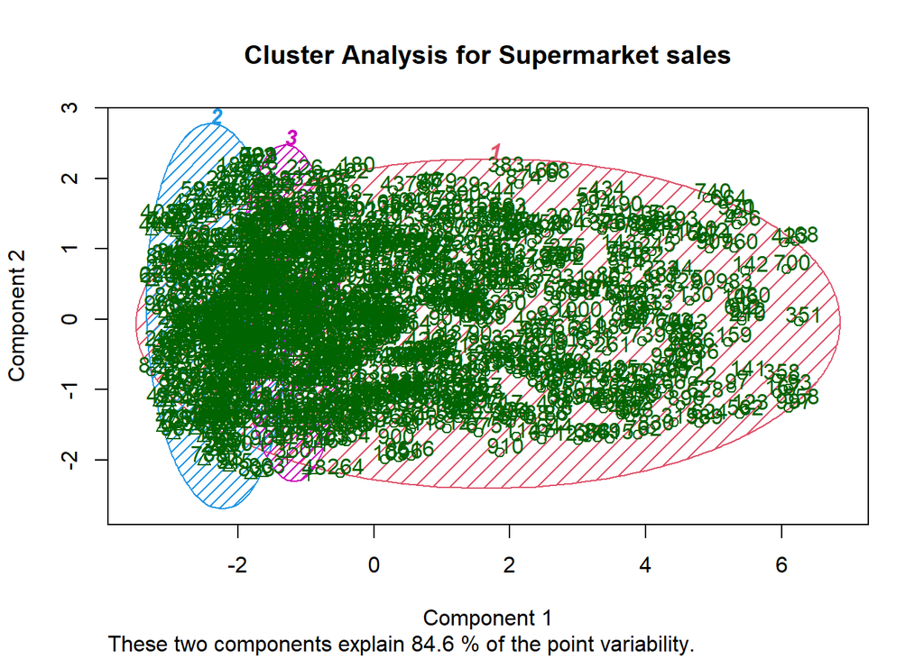

```r
clusplot(df, model$cluster, color=TRUE, shade=TRUE,
         labels=2, lines=1,main='Cluster Analysis for Supermarket sales')
```

From our plot, we see that the first 2 components explain 84.6 % of the point variability. Weights are calculated for each variable and cluster. They are a measure of the relative importance of each variable with regards to the membership of the observations to that cluster. The weights are incorporated into the distance function, typically reducing the distance for more important variables. Weights remain stored in the model and we can check them as follows:

```r
round(model$weights*100,2)
```

```
##   Unit.price Quantity Tax cogs gross.income Rating Total
## 1          0        0   0    0            0  99.99     0
## 2          0        0  50    0           50   0.00     0
## 3          0        0  50    0           50   0.00     0
```

### Feature Ranking

We will use the FSelector Package. This is a package containing functions for selecting attributes from a given dataset. Loading the required package.

```r
suppressWarnings(
        suppressMessages(if
                         (!require(FSelector, quietly=TRUE))
                install.packages("FSelector")))
library(FSelector)
```

From the FSelector package, we use the correlation coefficient as a unit of valuation. This is be one of the several algorithms contained in the FSelector package that can be used to rank the variables.

```r
Scores <- linear.correlation(Total~.,df)
Scores
```

```
##              attr_importance
## Unit.price         0.6339621
## Quantity           0.7055102
## Tax                1.0000000
## cogs               1.0000000
## gross.income       1.0000000
## Rating             0.0364417
```

From the output above, we observe a list containing rows of variables on the left and score on the right. In order to make a decision, we define a cutoff i.e. suppose we want to use the top 5 representative variables, through the use of the cutoff.k function included in the FSelector package.

```r
Subset <- cutoff.k(Scores, 5)
as.data.frame(Subset)
```

```
##         Subset
## 1          Tax
## 2         cogs
## 3 gross.income
## 4     Quantity
## 5   Unit.price
```

We could also set cutoff as a percentage which would indicate that we would want to work with the percentage of the best variables.

```r
Subset2 <-cutoff.k.percent(Scores, 0.4)
as.data.frame(Subset2)
```

```
##   Subset2
## 1     Tax
## 2    cogs
```

Instead of using the scores for the correlation coefficient, we can use an entropy - based approach.

```r
Scores2 <- information.gain(Total~., df)
Scores2
```

```
##              attr_importance
## Unit.price         0.3084863
## Quantity           0.4211154
## Tax                1.6094379
## cogs               1.6094379
## gross.income       1.6094379
## Rating             0.0000000
```

Choosing variables by cutoff method.

```r
Subset3 <- cutoff.k(Scores2, 5)
as.data.frame(Subset3)
```

```
##        Subset3
## 1          Tax
## 2         cogs
## 3 gross.income
## 4     Quantity
## 5   Unit.price
```